# Footprint 26: World Cup 2026 fan cost and carbon model

A reproducible bottom-up model of fan travel cost and emissions for the 2026 FIFA World Cup (USA / Canada / Mexico), using real venue coordinates, confirmed match allocations, and published emission factors.

**Run:** `Kernel -> Restart & Run All`. All reference data is embedded inline; no external files are required.

**Scope:** fan travel + lodging only. Construction, operations, and team/official travel are excluded (additive, so totals here are lower bounds).

**Outputs:** distance matrix, per-fan journey cost/carbon under three accounting methods, tournament rollup, host-city grid comparison, mitigation-lever estimates.

Findings and interpretation are written up separately in `Findings.md` / `Findings.html`.

**Dependencies:** `numpy`, `pandas`, `matplotlib`.

## 1. Imports and configuration

```python
import numpy as np
import pandas as pd
import matplotlib.pyplot as plt
from dataclasses import dataclass
from itertools import combinations

GREEN, INK, GREY, AMBER, RED = "#1B7A4B", "#14342A", "#5A6B62", "#B5651D", "#c0392b"
plt.rcParams.update({
    'font.family': 'DejaVu Sans', 'figure.dpi': 110,
    'axes.edgecolor': '#cccccc', 'axes.linewidth': 0.8,
    'axes.grid': True, 'grid.color': '#eef3f0', 'grid.linewidth': 1, 'axes.axisbelow': True,
    'text.color': INK, 'axes.labelcolor': INK, 'xtick.color': GREY, 'ytick.color': GREY,
})
pd.set_option('display.float_format', lambda x: f'{x:,.2f}')
```

## 2. Reference data

### 2.1 Venues

```python
VENUES = pd.DataFrame([
    # id,  stadium,                  city,                  country, lat,      lon,       cap,   matches, grid(tCO2/kWh)
    ("ATL","Mercedes-Benz Stadium",  "Atlanta",             "USA", 33.7553, -84.4006,  71000, 9, 0.379),
    ("ARL","AT&T Stadium",           "Dallas (Arlington)",  "USA", 32.7473, -97.0945,  80000, 9, 0.401),
    ("NYNJ","MetLife Stadium",       "New York/New Jersey", "USA", 40.8135, -74.0745,  82500, 8, 0.245),
    ("LA", "SoFi Stadium",           "Los Angeles",         "USA", 33.9535,-118.3392,  70240, 8, 0.221),
    ("BOS","Gillette Stadium",       "Boston",              "USA", 42.0909, -71.2643,  65878, 6, 0.252),
    ("SEA","Lumen Field",            "Seattle",             "USA", 47.5952,-122.3316,  68740, 6, 0.094),
    ("MIA","Hard Rock Stadium",      "Miami",               "USA", 25.9580, -80.2389,  65326, 7, 0.401),
    ("KC", "Arrowhead Stadium",      "Kansas City",         "USA", 39.0489, -94.4839,  76416, 6, 0.512),
    ("HOU","NRG Stadium",            "Houston",             "USA", 29.6847, -95.4107,  72220, 7, 0.401),
    ("PHI","Lincoln Financial Field","Philadelphia",        "USA", 39.9008, -75.1675,  69596, 6, 0.298),
    ("SF", "Levi's Stadium",         "SF Bay Area",         "USA", 37.4030,-121.9700,  68500, 6, 0.221),
    ("MEX","Estadio Azteca",         "Mexico City",         "MEX", 19.3029, -99.1505,  87523, 5, 0.431),
    ("GDL","Estadio Akron",          "Guadalajara",         "MEX", 20.6817,-103.4628,  49850, 4, 0.431),
    ("MTY","Estadio BBVA",           "Monterrey",           "MEX", 25.6694,-100.2444,  53500, 4, 0.431),
    ("TOR","BMO Field",              "Toronto",             "CAN", 43.6332, -79.4185,  45000, 7, 0.110),
    ("VAN","BC Place",               "Vancouver",           "CAN", 49.2768,-123.1119,  54500, 6, 0.013),
], columns=["venue_id","stadium","city","country","lat","lon","capacity","matches","grid_tco2_per_kwh"])

assert VENUES.venue_id.is_unique
assert VENUES.matches.sum() == 104, VENUES.matches.sum()
assert VENUES.groupby("country").matches.sum().to_dict() == {"USA":78,"CAN":13,"MEX":13}
VENUES[["venue_id","city","country","capacity","matches"]]
```

|  | venue_id | city | country | capacity | matches |
| --- | --- | --- | --- | --- | --- |
| 0 | ATL | Atlanta | USA | 71000 | 9 |
| 1 | ARL | Dallas (Arlington) | USA | 80000 | 9 |
| 2 | NYNJ | New York/New Jersey | USA | 82500 | 8 |
| 3 | LA | Los Angeles | USA | 70240 | 8 |
| 4 | BOS | Boston | USA | 65878 | 6 |
| 5 | SEA | Seattle | USA | 68740 | 6 |
| 6 | MIA | Miami | USA | 65326 | 7 |
| 7 | KC | Kansas City | USA | 76416 | 6 |
| 8 | HOU | Houston | USA | 72220 | 7 |
| 9 | PHI | Philadelphia | USA | 69596 | 6 |
| 10 | SF | SF Bay Area | USA | 68500 | 6 |
| 11 | MEX | Mexico City | MEX | 87523 | 5 |
| 12 | GDL | Guadalajara | MEX | 49850 | 4 |
| 13 | MTY | Monterrey | MEX | 53500 | 4 |
| 14 | TOR | Toronto | CAN | 45000 | 7 |
| 15 | VAN | Vancouver | CAN | 54500 | 6 |

### 2.2 Emission and cost factors

Transport and lodging emission factors (kgCO2e per passenger-km, except hotel = per room-night). Sources: DEFRA/BEIS 2024 (transport, incl. aviation radiative-forcing uplift); Cornell Hotel Sustainability Benchmarking 2023 (lodging). `rf_multiplier` is the aviation non-CO2 uplift (IPCC consensus ~1.7-2.0). Cost factors are USD assumptions.

```python
EF = {
    "air_short_haul": 0.246,   # <1500 km, incl. RF
    "air_long_haul":  0.151,   # >1500 km, incl. RF
    "rail_intercity": 0.035,
    "coach_bus":      0.027,
    "car_petrol_avg": 0.170,
    "hotel_night":    16.5,    # per room-night
    "rf_multiplier":  1.9,
}
COST = {"air_per_km": 0.12, "ground_per_km": 0.06, "hotel_night": 220.0}
GROUND_THRESHOLD_KM = 600.0   # ground transport assumed feasible at/below this; fly above
EF
```

```
{'air_short_haul': 0.246,
 'air_long_haul': 0.151,
 'rail_intercity': 0.035,
 'coach_bus': 0.027,
 'car_petrol_avg': 0.17,
 'hotel_night': 16.5,
 'rf_multiplier': 1.9}
```

## 3. Distance matrix

Great-circle (haversine) distances between all venue pairs.

```python
EARTH_KM = 6371.0088

def haversine(lat1, lon1, lat2, lon2):
    lat1, lon1, lat2, lon2 = map(np.radians, (lat1, lon1, lat2, lon2))
    dlat, dlon = lat2 - lat1, lon2 - lon1
    a = np.sin(dlat/2)**2 + np.cos(lat1)*np.cos(lat2)*np.sin(dlon/2)**2
    return 2 * EARTH_KM * np.arcsin(np.sqrt(a))

def build_distance_matrix(venues=VENUES):
    ids = venues.venue_id.tolist()
    v = venues.set_index("venue_id")
    M = np.zeros((len(ids), len(ids)))
    for a, b in combinations(ids, 2):
        d = round(haversine(v.loc[a,"lat"], v.loc[a,"lon"], v.loc[b,"lat"], v.loc[b,"lon"]), 1)
        i, j = ids.index(a), ids.index(b)
        M[i, j] = M[j, i] = d
    return pd.DataFrame(M, index=ids, columns=ids)

DM = build_distance_matrix()
DM.loc[["VAN","TOR","LA"], ["MIA","MEX","SF"]]
```

|  | MIA | MEX | SF |
| --- | --- | --- | --- |
| VAN | 4,491.50 | 3,957.60 | 1,323.50 |
| TOR | 1,966.80 | 3,270.90 | 3,622.10 |
| LA | 3,754.00 | 2,500.00 | 504.60 |

## 4. Emissions engine

### 4.1 Accounting methods

Three methods differing only in stated assumptions:

| Method | Radiative forcing | Return legs | Ground on short hops |
| --- | --- | --- | --- |
| `FIFA_STYLE` | no (CO2 only) | no (one-way) | yes |
| `BOTTOM_UP` | yes | yes | yes |
| `ALL_FLY` | yes | yes | no |

```python
@dataclass(frozen=True)
class Method:
    name: str
    apply_rf: bool
    round_trip: bool
    ground_ok: bool

FIFA_STYLE = Method("FIFA-style (optimistic)", apply_rf=False, round_trip=False, ground_ok=True)
BOTTOM_UP  = Method("Bottom-up (realistic)",   apply_rf=True,  round_trip=True,  ground_ok=True)
ALL_FLY    = Method("All-fly (upper bound)",   apply_rf=True,  round_trip=True,  ground_ok=False)
```

### 4.2 Per-leg emissions

Mode choice: rail below the threshold (when allowed by the method), else air. Air factors already include RF; for CO2-only accounting the RF component is divided back out.

```python
def leg_emissions(distance_km, method, threshold=GROUND_THRESHOLD_KM):
    if distance_km <= 0:
        return 0.0
    if method.ground_ok and distance_km <= threshold:
        per_km, rf = EF["rail_intercity"], 1.0
    else:
        per_km = EF["air_short_haul"] if distance_km < 1500 else EF["air_long_haul"]
        rf = 1.0 if method.apply_rf else (1.0 / EF["rf_multiplier"])
    return distance_km * per_km * rf * (2.0 if method.round_trip else 1.0)

assert leg_emissions(4000, BOTTOM_UP) > leg_emissions(4000, FIFA_STYLE)
pd.Series({m.name: round(leg_emissions(4000, m), 1) for m in (FIFA_STYLE, BOTTOM_UP, ALL_FLY)},
          name="kgCO2e for a 4,000 km leg")
```

```
FIFA-style (optimistic)     317.90
Bottom-up (realistic)     1,208.00
All-fly (upper bound)     1,208.00
Name: kgCO2e for a 4,000 km leg, dtype: float64
```

## 5. Fan-journey simulator

A journey = origin distance (home -> first venue) + ordered venue sequence + nights per stop. Returns travel emissions, lodging emissions, total cost (USD), and intra-tournament distance.

```python
@dataclass
class FanItinerary:
    origin_air_km: float
    venue_sequence: list
    nights_per_stop: int = 3
    origin_long_haul: bool = True

@dataclass
class JourneyResult:
    travel_kg: float
    hotel_kg: float
    cost_usd: float
    intra_km: float
    @property
    def total_kg(self): return self.travel_kg + self.hotel_kg
    @property
    def total_t(self):  return self.total_kg / 1000.0

def simulate(it, method):
    o_factor = EF["air_long_haul"] if it.origin_long_haul else EF["air_short_haul"]
    rf = 1.0 if method.apply_rf else (1.0 / EF["rf_multiplier"])
    travel = it.origin_air_km * o_factor * rf * (2.0 if method.round_trip else 1.0)
    cost   = it.origin_air_km * COST["air_per_km"] * (2.0 if method.round_trip else 1.0)
    intra_km = 0.0
    for a, b in zip(it.venue_sequence, it.venue_sequence[1:]):
        d = DM.loc[a, b]
        intra_km += d
        travel += leg_emissions(d, method)
        cost   += d * (COST["ground_per_km"] if d <= GROUND_THRESHOLD_KM else COST["air_per_km"])
    nights = it.nights_per_stop * len(it.venue_sequence)
    hotel  = nights * EF["hotel_night"]
    cost  += nights * COST["hotel_night"]
    return JourneyResult(round(travel,1), round(hotel,1), round(cost,2), round(intra_km,1))
```

Reference itinerary used throughout: a long-haul (Europe-origin) fan attending six matches across all three host countries.

```python
EURO_FAN = FanItinerary(8200, ["TOR","MEX","SEA","ARL","MIA","NYNJ"], 3, True)
_r = simulate(EURO_FAN, BOTTOM_UP)
pd.Series({"intra_km": _r.intra_km, "matches": len(EURO_FAN.venue_sequence),
           "total_tCO2e": _r.total_t, "cost_usd": _r.cost_usd})
```

```
intra_km      13,279.30
matches            6.00
total_tCO2e        6.78
cost_usd       7,521.52
dtype: float64
```

## 6. Inter-city distance distribution

Distribution of the 120 venue-pair distances and the share above the ground-transport threshold.

```python
pairs = np.array([DM.iloc[i, j] for i in range(16) for j in range(i+1, 16)])
share_fly = (pairs > GROUND_THRESHOLD_KM).mean() * 100
pd.Series({"n_pairs": len(pairs), "max_km": pairs.max(), "mean_km": round(pairs.mean()),
           "pairs_above_600km": int((pairs > 600).sum()), "pct_require_flight": round(share_fly, 1)})
```

```
n_pairs                120.00
max_km               4,491.50
mean_km              2,359.00
pairs_above_600km      111.00
pct_require_flight      92.50
dtype: float64
```

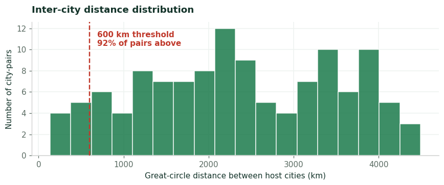

```python
fig, ax = plt.subplots(figsize=(8, 3.4))
ax.hist(pairs, bins=18, color=GREEN, alpha=0.85, zorder=3, edgecolor='white')
ax.axvline(GROUND_THRESHOLD_KM, color=RED, ls='--', lw=1.6, zorder=4)
ax.text(GROUND_THRESHOLD_KM+90, ax.get_ylim()[1]*0.82,
        f'600 km threshold\n{share_fly:.0f}% of pairs above', color=RED, fontsize=10, fontweight='bold')
ax.set_xlabel("Great-circle distance between host cities (km)")
ax.set_ylabel("Number of city-pairs")
ax.set_title("Inter-city distance distribution", fontweight='bold', color=INK, fontsize=12, loc='left', pad=12)
for s in ['top','right']: ax.spines[s].set_visible(False)
plt.tight_layout(); plt.show()
```

## 7. Per-fan emissions by accounting method

The reference itinerary costed under all three methods, and the ratio between the realistic and optimistic totals.

```python
rows = []
for m in (FIFA_STYLE, BOTTOM_UP, ALL_FLY):
    r = simulate(EURO_FAN, m)
    rows.append({"method": m.name, "travel_t": r.travel_kg/1000, "hotel_t": r.hotel_kg/1000,
                 "total_t": r.total_t, "cost_usd": r.cost_usd})
gap_df = pd.DataFrame(rows).set_index("method")
gap = gap_df.loc["Bottom-up (realistic)","total_t"] / gap_df.loc["FIFA-style (optimistic)","total_t"]
print(f"accounting gap (bottom-up / FIFA-style) = {gap:.2f}x")
gap_df
```

```
accounting gap (bottom-up / FIFA-style) = 3.39x
```

| method | travel_t | hotel_t | total_t | cost_usd |
| --- | --- | --- | --- | --- |
| FIFA-style (optimistic) | 1.71 | 0.30 | 2.00 | 6,537.52 |
| Bottom-up (realistic) | 6.49 | 0.30 | 6.78 | 7,521.52 |
| All-fly (upper bound) | 6.49 | 0.30 | 6.78 | 7,521.52 |

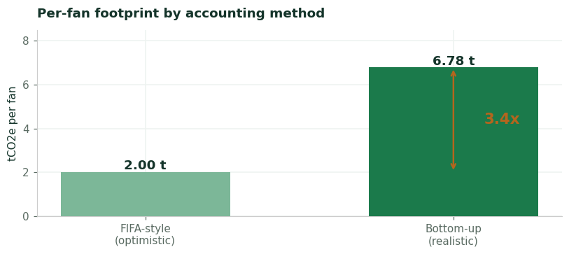

```python
fig, ax = plt.subplots(figsize=(7.5, 3.4))
methods = ["FIFA-style\n(optimistic)", "Bottom-up\n(realistic)"]
totals  = [gap_df.loc["FIFA-style (optimistic)","total_t"], gap_df.loc["Bottom-up (realistic)","total_t"]]
bars = ax.bar(methods, totals, color=["#7cb798", GREEN], width=0.55, zorder=3)
for b, v in zip(bars, totals):
    ax.text(b.get_x()+b.get_width()/2, v+0.12, f"{v:.2f} t", ha="center", fontweight="bold", fontsize=12)
ax.annotate("", xy=(1, totals[1]), xytext=(1, totals[0]),
            arrowprops=dict(arrowstyle="<->", color=AMBER, lw=1.6))
ax.text(1.10, sum(totals)/2, f"{gap:.1f}x", color=AMBER, fontweight="bold", fontsize=14, va="center")
ax.set_ylabel("tCO2e per fan"); ax.set_ylim(0, max(totals)*1.25)
ax.set_title("Per-fan footprint by accounting method", fontweight="bold", color=INK, fontsize=12, loc="left", pad=12)
for s in ['top','right']: ax.spines[s].set_visible(False)
plt.tight_layout(); plt.show()
```

## 8. Non-ticket cost decomposition

Out-of-pocket cost (excluding match tickets) for the reference itinerary, split into origin flight, intra-tournament flights, and lodging.

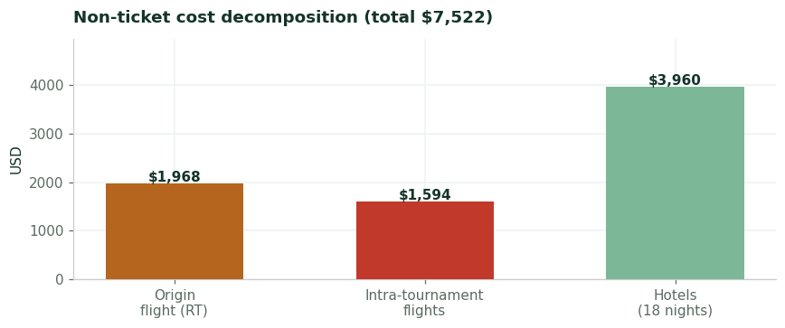

```python
origin_cost = EURO_FAN.origin_air_km * COST["air_per_km"] * 2
intra_cost  = sum(DM.loc[a,b] * (COST["ground_per_km"] if DM.loc[a,b] <= GROUND_THRESHOLD_KM else COST["air_per_km"])
                  for a,b in zip(EURO_FAN.venue_sequence, EURO_FAN.venue_sequence[1:]))
hotel_cost  = EURO_FAN.nights_per_stop * len(EURO_FAN.venue_sequence) * COST["hotel_night"]

comp = pd.Series({"origin_flight_RT": origin_cost, "intra_flights": intra_cost, "hotels_18n": hotel_cost})
fig, ax = plt.subplots(figsize=(8, 3.4))
bars = ax.bar(["Origin\nflight (RT)","Intra-tournament\nflights","Hotels\n(18 nights)"],
              comp.values, color=[AMBER, RED, "#7cb798"], zorder=3, width=0.55)
for b, v in zip(bars, comp.values):
    ax.text(b.get_x()+b.get_width()/2, v+40, f"${v:,.0f}", ha="center", fontweight="bold")
ax.set_ylabel("USD"); ax.set_ylim(0, comp.max()*1.25)
ax.set_title(f"Non-ticket cost decomposition (total ${comp.sum():,.0f})",
             fontweight="bold", color=INK, fontsize=12, loc="left", pad=12)
for s in ['top','right']: ax.spines[s].set_visible(False)
plt.tight_layout(); plt.show()
```

### 8.1 Reported ticket prices, 2022 vs 2026

Sourced figures (ESPN, Business Standard, Gulf News, early-mid 2026), shown for reference.

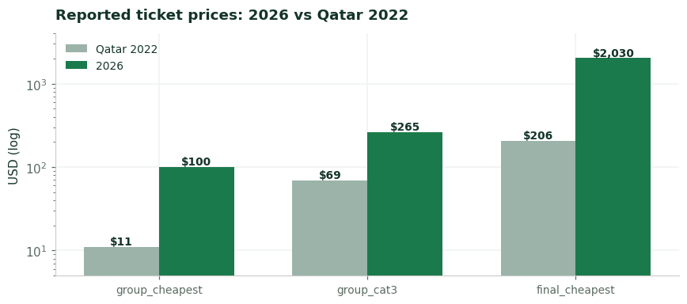

|  | Qatar_2022 | WC_2026 |
| --- | --- | --- |
| group_cheapest | 11 | 100 |
| group_cat3 | 69 | 265 |
| final_cheapest | 206 | 2030 |

```python
tickets = pd.DataFrame({
    "Qatar_2022": [11, 69, 206],
    "WC_2026":    [100, 265, 2030],
}, index=["group_cheapest", "group_cat3", "final_cheapest"])

fig, ax = plt.subplots(figsize=(8, 3.6))
x = np.arange(len(tickets)); w = 0.36
b1 = ax.bar(x-w/2, tickets.Qatar_2022, w, label="Qatar 2022", color="#9bb3a8", zorder=3)
b2 = ax.bar(x+w/2, tickets.WC_2026,    w, label="2026",       color=GREEN,     zorder=3)
ax.set_yscale("log"); ax.set_ylabel("USD (log)"); ax.set_ylim(5, 4000)
for bars in (b1, b2):
    for b in bars:
        ax.text(b.get_x()+b.get_width()/2, b.get_height()*1.06, f"${b.get_height():,.0f}",
                ha="center", fontsize=9, fontweight="bold")
ax.set_xticks(x); ax.set_xticklabels(tickets.index, fontsize=9)
ax.legend(frameon=False, fontsize=9, loc="upper left")
ax.set_title("Reported ticket prices: 2026 vs Qatar 2022", fontweight="bold", color=INK, fontsize=12, loc="left", pad=12)
for s in ['top','right']: ax.spines[s].set_visible(False)
plt.tight_layout(); plt.show()
tickets
```

## 9. Tournament rollup

Per-fan results scaled by an **estimated** travelling-fan population and origin mix. These population inputs are assumptions, not measured attendance; the resulting total is an order-of-magnitude figure. Benchmark anchors (Qatar reported 3.6 Mt; FIFA -50%-by-2030 implied ceiling) are sourced.

```python
TOTAL_TRAVELLING_FANS = 2_500_000   # assumption
SEGMENTS = {  # name: (share, origin_km, long_haul, route)
    "Domestic (CONCACAF)": (0.55, 1200,  False, ["LA","SEA","ARL"]),
    "South America":       (0.12, 7500,  True,  ["MIA","ARL","NYNJ"]),
    "Europe":              (0.20, 8200,  True,  ["TOR","BOS","NYNJ"]),
    "Africa":              (0.05, 11000, True,  ["MEX","HOU","ATL"]),
    "Asia/Oceania":        (0.08, 12500, True,  ["VAN","SF","LA"]),
}
QATAR_REPORTED_MT = 3.6
TARGET_2030_MT    = 3.6 * 0.5

def rollup(method):
    out = []
    for name,(share,km,lh,route) in SEGMENTS.items():
        per_fan_t = simulate(FanItinerary(km, route, 3, lh), method).total_t
        pop = TOTAL_TRAVELLING_FANS * share
        out.append({"segment":name, "pop":int(pop), "per_fan_t":round(per_fan_t,2),
                    "segment_t":round(per_fan_t*pop)})
    return pd.DataFrame(out)

roll_bu = rollup(BOTTOM_UP)
total_bu_mt = roll_bu.segment_t.sum()/1e6
print(f"fan travel+lodging (bottom-up) = {total_bu_mt:.2f} Mt CO2e")
print(f"  vs Qatar reported (3.6 Mt)   = {total_bu_mt/QATAR_REPORTED_MT:.2f}x")
print(f"  vs 2030 interim ceiling      = {total_bu_mt/TARGET_2030_MT:.2f}x")
roll_bu.set_index("segment")
```

```
fan travel+lodging (bottom-up) = 6.86 Mt CO2e
  vs Qatar reported (3.6 Mt)   = 1.90x
  vs 2030 interim ceiling      = 3.81x
```

| segment | pop | per_fan_t | segment_t |
| --- | --- | --- | --- |
| Domestic (CONCACAF) | 1375000 | 2.02 | 2775988 |
| South America | 300000 | 3.63 | 1088790 |
| Europe | 500000 | 2.98 | 1490800 |
| Africa | 125000 | 4.63 | 578300 |
| Asia/Oceania | 200000 | 4.61 | 922000 |

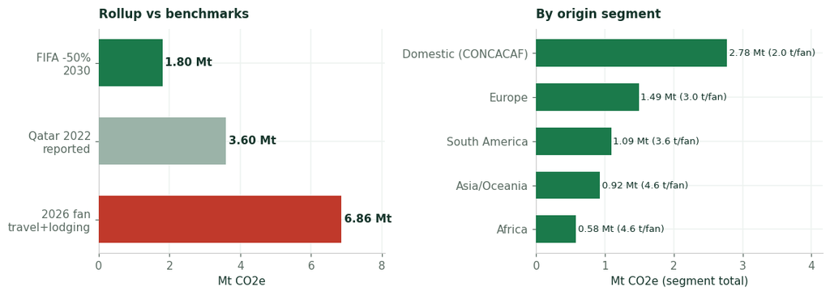

```python
fig, axes = plt.subplots(1, 2, figsize=(10.5, 3.8))
ax = axes[0]
labels = ["FIFA -50%\n2030", "Qatar 2022\nreported", "2026 fan\ntravel+lodging"]
vals   = [TARGET_2030_MT, QATAR_REPORTED_MT, total_bu_mt]
bars = ax.barh(labels, vals, color=[GREEN, "#9bb3a8", RED], height=0.6, zorder=3)
for b, v in zip(bars, vals):
    ax.text(v+0.08, b.get_y()+b.get_height()/2, f"{v:.2f} Mt", va="center", fontweight="bold", fontsize=10)
ax.set_xlabel("Mt CO2e"); ax.set_xlim(0, total_bu_mt*1.18); ax.invert_yaxis()
ax.set_title("Rollup vs benchmarks", fontweight="bold", color=INK, fontsize=11, loc="left", pad=10)
for s in ['top','right']: ax.spines[s].set_visible(False)

ax = axes[1]
seg = roll_bu.sort_values("segment_t")
bars = ax.barh(seg.segment, seg.segment_t/1e6, color=GREEN, height=0.62, zorder=3)
for b, v, pf in zip(bars, seg.segment_t/1e6, seg.per_fan_t):
    ax.text(v+0.03, b.get_y()+b.get_height()/2, f"{v:.2f} Mt ({pf:.1f} t/fan)", va="center", fontsize=8.5)
ax.set_xlabel("Mt CO2e (segment total)"); ax.set_xlim(0, seg.segment_t.max()/1e6*1.5)
ax.set_title("By origin segment", fontweight="bold", color=INK, fontsize=11, loc="left", pad=10)
for s in ['top','right']: ax.spines[s].set_visible(False)
plt.tight_layout(); plt.show()
```

## 10. Host-city grid intensity

Stadium-operations emissions scale with local electricity carbon intensity. Venues ranked below.

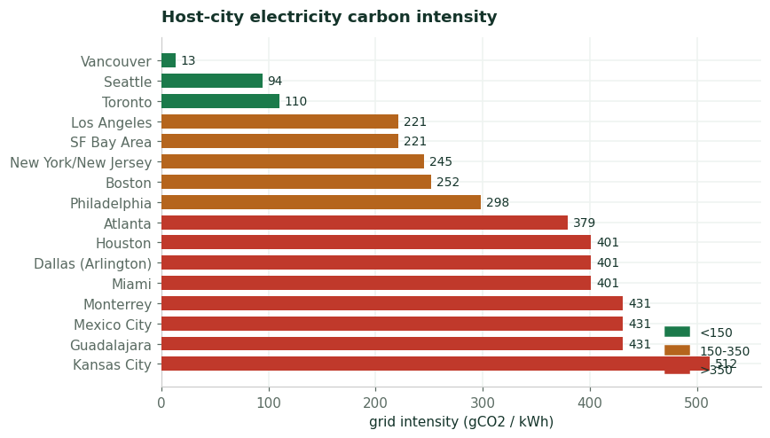

```
max/min ratio = 39x
```

```python
vg = VENUES.sort_values("grid_tco2_per_kwh").copy()
vg["grid_g"] = vg.grid_tco2_per_kwh * 1000
colors = [GREEN if g < 150 else (AMBER if g < 350 else RED) for g in vg.grid_g]

fig, ax = plt.subplots(figsize=(8, 4.6))
bars = ax.barh(vg.city, vg.grid_g, color=colors, height=0.7, zorder=3)
for b, g in zip(bars, vg.grid_g):
    ax.text(g+5, b.get_y()+b.get_height()/2, f"{g:.0f}", va="center", fontsize=9)
ax.set_xlabel("grid intensity (gCO2 / kWh)"); ax.set_xlim(0, 560); ax.invert_yaxis()
ax.set_title("Host-city electricity carbon intensity", fontweight="bold", color=INK, fontsize=12, loc="left", pad=12)
import matplotlib.patches as mp
ax.legend(handles=[mp.Patch(color=GREEN,label="<150"), mp.Patch(color=AMBER,label="150-350"),
                   mp.Patch(color=RED,label=">350")], loc="lower right", frameon=False, fontsize=9)
for s in ['top','right']: ax.spines[s].set_visible(False)
plt.tight_layout(); plt.show()
print(f"max/min ratio = {vg.grid_g.max()/vg.grid_g.min():.0f}x")
```

## 11. Mitigation-lever estimates

Per-fan footprint under three interventions vs the realistic baseline: geographic clustering of the route, a generous rail-shift assumption (1000 km threshold), and attending four matches instead of six.

```python
def simulate_threshold(it, method, threshold):
    o_factor = EF["air_long_haul"] if it.origin_long_haul else EF["air_short_haul"]
    rf = 1.0 if method.apply_rf else (1.0/EF["rf_multiplier"])
    travel = it.origin_air_km*o_factor*rf*(2.0 if method.round_trip else 1.0)
    for a,b in zip(it.venue_sequence, it.venue_sequence[1:]):
        travel += leg_emissions(DM.loc[a,b], method, threshold=threshold)
    travel += it.nights_per_stop*len(it.venue_sequence)*EF["hotel_night"]
    return travel/1000.0

base    = simulate(EURO_FAN, BOTTOM_UP).total_t
cluster = simulate(FanItinerary(8200, ["LA","SF","SEA","ARL","MIA","NYNJ"], 3, True), BOTTOM_UP).total_t
rail    = simulate_threshold(EURO_FAN, BOTTOM_UP, threshold=1000.0)
fewer   = simulate(FanItinerary(8200, ["TOR","MEX","MIA","NYNJ"], 3, True), BOTTOM_UP).total_t

levers = pd.DataFrame({
    "scenario": ["baseline", "geographic_clustering", "rail_shift_1000km", "attend_4_not_6"],
    "total_t":  [base, cluster, rail, fewer],
})
levers["pct_chg"] = ((levers.total_t - base) / base * 100).round(0)
levers
```

|  | scenario | total_t | pct_chg |
| --- | --- | --- | --- |
| 0 | baseline | 6.78 | 0.00 |
| 1 | geographic_clustering | 5.25 | -23.00 |
| 2 | rail_shift_1000km | 6.78 | 0.00 |
| 3 | attend_4_not_6 | 4.82 | -29.00 |

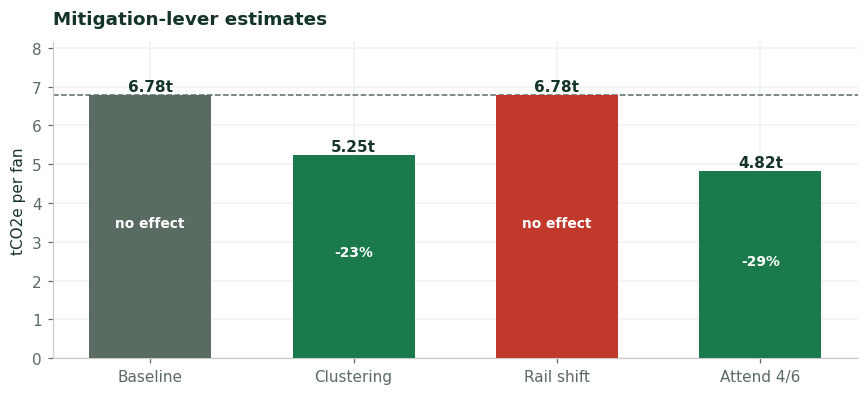

```python
fig, ax = plt.subplots(figsize=(8, 3.7))
labels = ["Baseline", "Clustering", "Rail shift", "Attend 4/6"]
vals   = levers.total_t.tolist()
cols   = [GREY, GREEN, RED if abs(vals[2]-base) < 0.01 else GREEN, GREEN]
bars = ax.bar(labels, vals, color=cols, width=0.6, zorder=3)
for b, v, p in zip(bars, vals, levers["pct_chg"]):
    ax.text(b.get_x()+b.get_width()/2, v+0.1, f"{v:.2f}t", ha="center", fontweight="bold", fontsize=10)
    tag = "no effect" if abs(p) < 1 else f"{p:+.0f}%"
    ax.text(b.get_x()+b.get_width()/2, v/2, tag, ha="center", color="white", fontsize=9, fontweight="bold")
ax.axhline(base, ls="--", color=GREY, lw=1, zorder=2)
ax.set_ylabel("tCO2e per fan"); ax.set_ylim(0, base*1.2)
ax.set_title("Mitigation-lever estimates", fontweight="bold", color=INK, fontsize=12, loc="left", pad=12)
for s in ['top','right']: ax.spines[s].set_visible(False)
plt.tight_layout(); plt.show()
```

## 12. Key outputs summary

Consolidated numeric results produced by this notebook. Interpretation is in the companion write-up.

```python
summary = pd.Series({
    "venues": len(VENUES),
    "matches_total": int(VENUES.matches.sum()),
    "max_intercity_km": pairs.max(),
    "mean_intercity_km": round(pairs.mean()),
    "pct_pairs_require_flight": round(share_fly, 1),
    "ref_fan_intra_km": simulate(EURO_FAN, BOTTOM_UP).intra_km,
    "ref_fan_total_tCO2e_realistic": round(simulate(EURO_FAN, BOTTOM_UP).total_t, 2),
    "ref_fan_total_tCO2e_optimistic": round(simulate(EURO_FAN, FIFA_STYLE).total_t, 2),
    "accounting_gap_x": round(gap, 2),
    "ref_fan_nonticket_cost_usd": round(simulate(EURO_FAN, BOTTOM_UP).cost_usd),
    "rollup_bottom_up_Mt": round(total_bu_mt, 2),
    "rollup_vs_qatar_x": round(total_bu_mt/QATAR_REPORTED_MT, 2),
    "rollup_vs_2030_target_x": round(total_bu_mt/TARGET_2030_MT, 2),
    "grid_max_min_ratio": round(vg.grid_g.max()/vg.grid_g.min()),
    "lever_clustering_pct": int(levers.loc[1,"pct_chg"]),
    "lever_attend4_pct": int(levers.loc[3,"pct_chg"]),
}, name="value")
summary.to_frame()
```

|  | value |
| --- | --- |
| venues | 16.00 |
| matches_total | 104.00 |
| max_intercity_km | 4,491.50 |
| mean_intercity_km | 2,359.00 |
| pct_pairs_require_flight | 92.50 |
| ref_fan_intra_km | 13,279.30 |
| ref_fan_total_tCO2e_realistic | 6.78 |
| ref_fan_total_tCO2e_optimistic | 2.00 |
| accounting_gap_x | 3.39 |
| ref_fan_nonticket_cost_usd | 7,522.00 |
| rollup_bottom_up_Mt | 6.86 |
| rollup_vs_qatar_x | 1.90 |
| rollup_vs_2030_target_x | 3.81 |
| grid_max_min_ratio | 39.00 |
| lever_clustering_pct | -23.00 |
| lever_attend4_pct | -29.00 |